# Task4_Large_Distributions

Chloe Huang

6/4/2021

```r
library(nycflights13)
library(tidyverse)
```

## Plots

1. The count of flight hours of all the flights

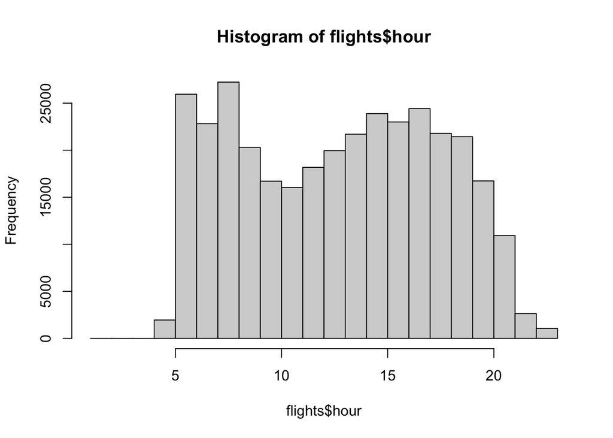

```r
hist(flights$hour)
```

2. The scatter plot for departure delays and arrival delays.

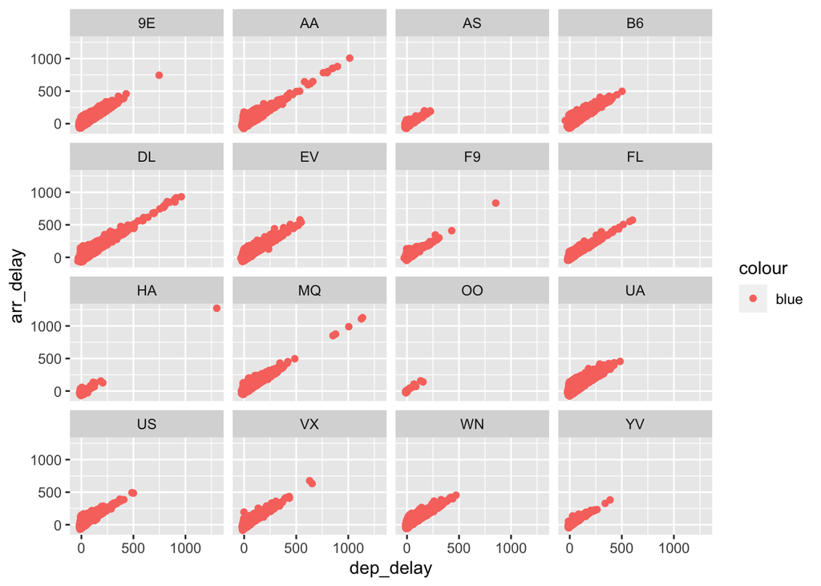

```r
ggplot(data = flights) +
  geom_point(mapping = aes(x = dep_delay  , y = arr_delay, color = "blue")) +
  facet_wrap(~ carrier)
```

3. The boxplot for departure delays and arrival delays.

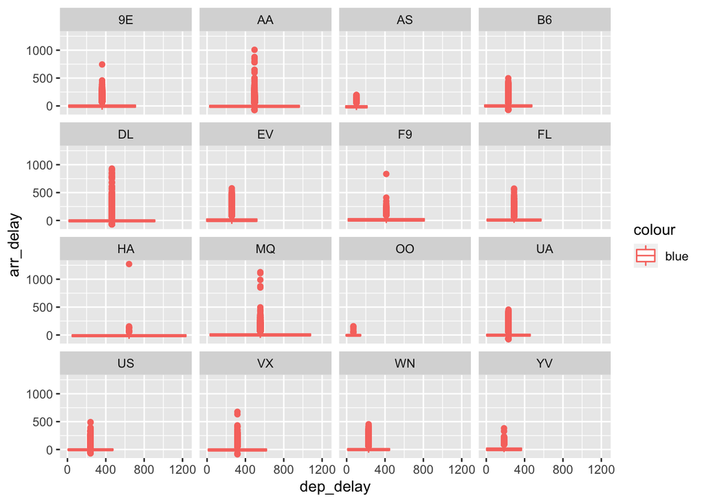

```r
ggplot(data = flights) +
  geom_boxplot(mapping = aes(x = dep_delay  , y = arr_delay, color = "blue")) +
  facet_wrap(~ carrier)
```

4. The relationship of the air time and the distance in bin2d

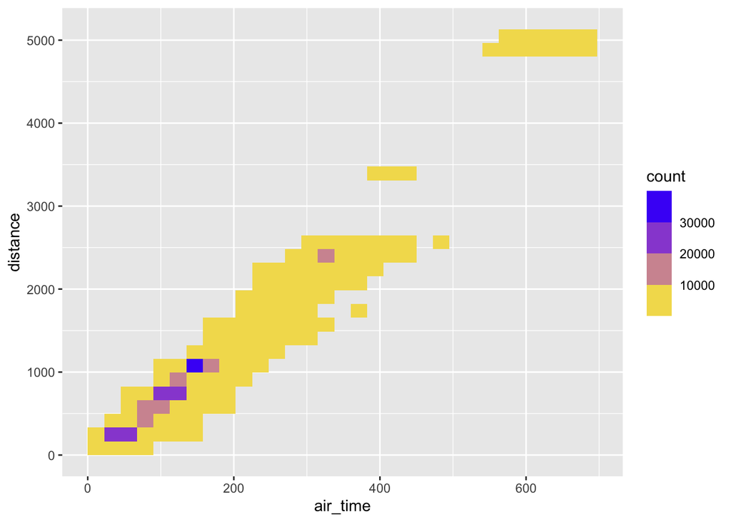

```r
ggplot(flights) +
  geom_bin2d(aes(air_time, distance)) +
  scale_fill_binned(low = "yellow", high = "blue")
```

5.The relationship of the air time and the distance in smooth

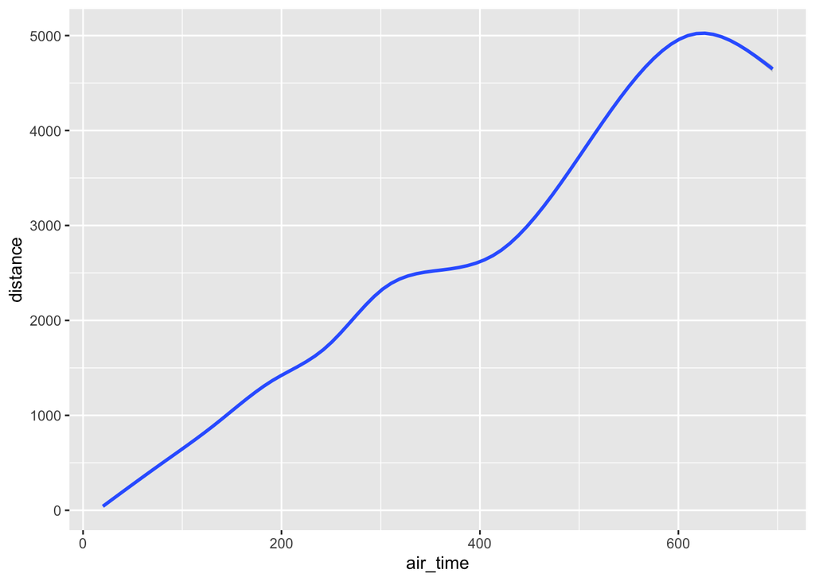

```r
ggplot(flights) +
geom_smooth(aes(air_time, distance))
```

## Summary

**Why did you choose to make those types f charts?** I used the histogram because I want to see which hours are more common or less common for the all flights. The scatter plot helps me to see what are the hot spot for the total delay time from each carrier. The bin2d help me understand the relationship between the air time and the distance.